# Titanic Writeup

Kaggle is a website that hosts data analytics competitions. Their Titanic competition is their most well known competition for beginner analysts to practice and compare their results with other analysts. The competition provides two data sets: a training and a testing set. You are to use the training set to make a predictive model to predict which passengers survive the Titanic’s sinking. You are then to apply the model to the test set to predict which passengers will live. Kaggle tells you which of the training set passengers live. They do not tell you which of the testing set passengers live.

To start the analysis, I need to load the data.

```r
setwd("H:/Google Drive/Stats Projects/Data Sets")
titanic_train <- read.csv("Titanic_train.csv", stringsAsFactors = FALSE)
titanic_test <- read.csv("Titanic_test.csv", stringsAsFactors = FALSE)
```

I examine my data to see what I am working with. I want to check for missing values first, so I use the summary function.

```r
summary(titanic_train)
```

```
##   PassengerId       Survived          Pclass          Name
##  Min.   :  1.0   Min.   :0.0000   Min.   :1.000   Length:891
##  1st Qu.:223.5   1st Qu.:0.0000   1st Qu.:2.000   Class :character
##  Median :446.0   Median :0.0000   Median :3.000   Mode  :character
##  Mean   :446.0   Mean   :0.3838   Mean   :2.309
##  3rd Qu.:668.5   3rd Qu.:1.0000   3rd Qu.:3.000
##  Max.   :891.0   Max.   :1.0000   Max.   :3.000
##
##      Sex                 Age            SibSp           Parch
##  Length:891         Min.   : 0.42   Min.   :0.000   Min.   :0.0000
##  Class :character   1st Qu.:20.12   1st Qu.:0.000   1st Qu.:0.0000
##  Mode  :character   Median :28.00   Median :0.000   Median :0.0000
##                     Mean   :29.70   Mean   :0.523   Mean   :0.3816
##                     3rd Qu.:38.00   3rd Qu.:1.000   3rd Qu.:0.0000
##                     Max.   :80.00   Max.   :8.000   Max.   :6.0000
##                     NA's   :177
##     Ticket               Fare           Cabin             Embarked
##  Length:891         Min.   :  0.00   Length:891         Length:891
##  Class :character   1st Qu.:  7.91   Class :character   Class :character
##  Mode  :character   Median : 14.45   Mode  :character   Mode  :character
##                     Mean   : 32.20
##                     3rd Qu.: 31.00
##                     Max.   :512.33
##
```

I see that there are 177 missing age values, and I anticipate many more missing age values in the test set. I combine the training and the testing set into one dataframe called ‘full’ so I can impute in one step. Combining the dataframes provides more information to impute with. I will have to add a column of NA’s to the test set for the Survived variable. Also, many of the variables would be more useful as factors. I will convert all the character data to factors and run the summary on the new dataframe.

```r
library('dplyr')
```

```r
titanic_test$Survived <- rep(NA, nrow(titanic_test))
full <- bind_rows(titanic_train, titanic_test)

#Convert variables to factors
full$Embarked <- as.factor(full$Embarked)
full$Pclass <- as.factor(full$Pclass)
full$Sex <- as.factor(full$Sex)
full$Ticket <- as.factor(full$Ticket)
full$Cabin <- as.factor(full$Cabin)
full$Embarked <- as.factor(full$Embarked)

summary(full)
```

```
##   PassengerId      Survived      Pclass      Name               Sex
##  Min.   :   1   Min.   :0.0000   1:323   Length:1309        female:466
##  1st Qu.: 328   1st Qu.:0.0000   2:277   Class :character   male  :843
##  Median : 655   Median :0.0000   3:709   Mode  :character
##  Mean   : 655   Mean   :0.3838
##  3rd Qu.: 982   3rd Qu.:1.0000
##  Max.   :1309   Max.   :1.0000
##                 NA's   :418
##       Age            SibSp            Parch            Ticket
##  Min.   : 0.17   Min.   :0.0000   Min.   :0.000   CA. 2343:  11
##  1st Qu.:21.00   1st Qu.:0.0000   1st Qu.:0.000   1601    :   8
##  Median :28.00   Median :0.0000   Median :0.000   CA 2144 :   8
##  Mean   :29.88   Mean   :0.4989   Mean   :0.385   3101295 :   7
##  3rd Qu.:39.00   3rd Qu.:1.0000   3rd Qu.:0.000   347077  :   7
##  Max.   :80.00   Max.   :8.0000   Max.   :9.000   347082  :   7
##  NA's   :263                                      (Other) :1261
##       Fare                     Cabin      Embarked
##  Min.   :  0.000                  :1014    :  2
##  1st Qu.:  7.896   C23 C25 C27    :   6   C:270
##  Median : 14.454   B57 B59 B63 B66:   5   Q:123
##  Mean   : 33.295   G6             :   5   S:914
##  3rd Qu.: 31.275   B96 B98        :   4
##  Max.   :512.329   C22 C26        :   4
##  NA's   :1         (Other)        : 271
```

The summary shows 263 NA’s in Age, 1 NA in Fare, 2 blank entries in Embarked, and 1014 blank entries in Cabin. There are also the 418 NA’s that I added in the Survived column from the test set. To impute, I set the blank entries in Embarked to NA. I use the ‘mice’ package and the cart method to impute. I choose to impute with cart because it will fill in missing numerical and categorical values. I omit the PassengerID, Ticket and Name columns because they have unique values in them. I omit the Cabin column because it has too many missing values.

```r
full$Embarked[830] <- NA
full$Embarked[62] <- NA

library(mice)
imp <- full

tempData <- mice(imp[,c(2,3,5:8, 10, 12)],m=1,maxit=50,meth='cart',seed=500, printFlag =  FALSE)

imp <- complete(tempData,1)
full$Age <- imp$Age
full$Fare <- imp$Fare
full$Embarked <- imp$Embarked
```

I apply the factor function to full$Embarked to remove the fourth factor, “”.

```r
full$Embarked <- factor(full$Embarked)
```

Now that I filled in the missing values, I have to make use of the remaining data. First I want to create a Family variable by adding the SibSp and Parch variables.

```r
full$Family <- full$Parch + full$SibSp
```

Next I want to make use of the Cabin variable. I examine the first six non-empty rows of the Cabin column.

```r
head(subset(full, full$Cabin != ""))$Cabin
```

```
## [1] C85  C123 E46  G6   C103 D56
## 187 Levels:  A10 A11 A14 A16 A18 A19 A20 A21 A23 A24 A26 A29 A31 ... T
```

```r
full$Letter <- substr(full$Cabin, 1, 1)
full$Letter[which(full$Letter == "")] <- "UNK"
```

Now the hard part. I want to get the Cabin number, but some of the numbers are one digit, some are two digits, and some of the numbers are three digits. I start by taking the second, third, and fourth characters together in the Cabin string.

```r
full$Number <- substr(full$Cabin, 2, 4)
subset(full, Number != "")$Number
```

```
##   [1] "85"  "123" "46"  "6"   "103" "56"  "6"   "23 " "78"  "33"  "30"
##  [12] "52"  "28"  "83"  "33"  " G7" "23 " "31"  "5"   "10 " "26"  "110"
##  [23] "58 " "101" "26"  " E6" "47"  "123" "86"  "2"   "2"   "33"  "19"
##  [34] "7"   "49"  "4"   "32"  "2"   "4"   "80"  "6"   "31"  "36"  "15"
##  [45] "93"  "83"  "78"  "35"  "6"   "87"  "77"  "67"  "94"  "125" "99"
##  [56] "118" "7"   "19"  "49"  "22 " "106" "58 " "101" "22 " "65"  "36"
##  [67] "54"  "57 " "7"   "34"  "32"  "18"  "124" "91"  "2"   "40"  "2"
##  [78] "23 " "33"  "128" "33"  "37"  "35"  "50"  "82"  "96 " "36"  "6"
##  [89] "78"  "10"  "52"  "44"  "96 " "23 " "34"  "104" "111" "92"  "38"
## [100] "21"  "12"  "63"  "14"  "49"  "93"  "37"  "30"  "20"  "22 " "79"
## [111] "65"  "25"  "46"  "33"  "73"  "18"  "95"  "38"  "39"  "22"  "86"
## [122] "70"  "16"  "67"  "101" "25"  "44"  "68"  "10"  "68"  "41"  "20"
## [133] "20"  "125" "4"   "19"  "50"  "9"   "23"  "50"  "35"  "33"  "26"
## [144] "48"  "58"  "126" "71"  "51 " "49"  "5"   "20"  "68"  " G6" "62 "
## [155] "24"  "24"  "90"  "124" "126" " G7" "45"  "101" "8"   "5"   "101"
## [166] "45"  "46"  "57 " "22"  "30"  "121" "77"  "96 " "11"  "77"  "38"
## [177] "3"   "20"  "6"   "82 " "17"  "96 " "36"  "8"   "102" "69"  "121"
## [188] "28"  "49"  "47"  "92"  "28"  "17"  "17"  "24"  "35"  "51 " "50"
## [199] "42"  "148" "45"  "31"  "57 " "36"  "21"  "78"  "34"  "19"  "9"
## [210] "15"  "31"  "23 " " G6" "61"  "57 " "53"  "23 " "43"  "130" "132"
## [221] "101" "55 " "71"  "46"  "116" "29"  "55 " "6"   "6"   "28"  "51"
## [232] "57 " "46"  "54"  "97"  "22"  "10"  "116" "4"   "45"  "52"  "30"
## [243] "58 " "34"  "62 " "11"  "11"  "80"  "33"  "85"  "37"  "86"  "34"
## [254] "21"  "89"  "6"   "89"  "45"  " E4" "34"  "26"  "22 " "69"  "32"
## [265] "78"  " E5" "2"   "4"   "18"  "106" "51 " "10 " "60"  "101" "50"
## [276] "39 " "52 " "34"  "39"  "24"  "28"  "31"  "41"  "7"   "40"  "38"
## [287] "80"  "78"  "105"
```

I see an issue. The string for row 76 is " G7“. Namely, it has a letter. I take a closer look.

```r
full$Cabin[76]
```

```
## [1] F G73
## 187 Levels:  A10 A11 A14 A16 A18 A19 A20 A21 A23 A24 A26 A29 A31 ... T
```

There are two letters in this Cabin Id. I am skeptical that the cabin data will yield much information, but I extract all the numbers. Also, some passengers had multiple cabins assigned to them. In those instances, I took the first cabin. I extract the numbers and convert it to a numerical variable.

```r
full$Number <- substr(full$Cabin, 2, 5)
full$Number[which(substr(full$Number, 2, 2) == "E" | substr(full$Number, 2, 2) == "G")] <- substr(full$Number[which(substr(full$Number, 2, 2) == "E" | substr(full$Number, 2, 2) == "G")], 3, 5)
full$Number[which(substr(full$Number, 4, 4) == "B" | substr(full$Number, 4, 4) == "C" | substr(full$Number, 4, 4) == "D")] <- substr(full$Number[which(substr(full$Number, 4, 4) == "B" | substr(full$Number, 4, 4) == "C" | substr(full$Number, 4, 4) == "D")], 1, 3)
full$Number[which(full$Number == "39 E")] <- 39
full$Number <- as.numeric(full$Number)
```

Next, I group the cabin numbers into groups of 25 and I convert them to a factor variable. Any missing numbers are given “UNK”

```r
full$Number[which(full$Number <= 25)] <- 25
full$Number[which(full$Number <= 50 & full$Number > 25)] <- 50
full$Number[which(full$Number <= 75 & full$Number > 50)] <- 75
full$Number[which(full$Number <= 100 & full$Number > 75)] <- 100
full$Number[which(full$Number <= 125 & full$Number > 100)] <- 125
full$Number[which(full$Number <= 150 & full$Number > 125)] <- 150
full$Number <- as.character(full$Number)
full$Number[which(is.na(full$Number))] <- "UNK"
full$Number <- as.factor(full$Number)
```

Since the majority of the Cabin information is missing, I create a column called “known”. If cabin information is known, I assign a TRUE. If not, FALSE. I think there is too much cabin information missing to yield any useful insights, but perhaps the data is not missing randomly.

```r
full$Known <- full$Letter != "UNK"
```

Next I look at the Name column.

```r
head(full$Name)
```

```
## [1] "Braund, Mr. Owen Harris"
## [2] "Cumings, Mrs. John Bradley (Florence Briggs Thayer)"
## [3] "Heikkinen, Miss. Laina"
## [4] "Futrelle, Mrs. Jacques Heath (Lily May Peel)"
## [5] "Allen, Mr. William Henry"
## [6] "Moran, Mr. James"
```

The Name column appears to have the passenger’s name as well as their title. The names are probably too unique to make use of, but the titles should be easy to use.

```r
full$Title <- sub(".*, ", "", full$Name)
full$Title <- sub(". .*", "", full$Title)
sort(table(full$Title))
```

```
##
##     Capt      Don     Dona Jonkheer     Lady      Mme      Sir       th
##        1        1        1        1        1        1        1        1
##    Major     Mlle       Ms      Col       Dr      Rev   Master      Mrs
##        2        2        2        4        8        8       61      197
##     Miss       Mr
##      260      757
```

There are 18 titles total. Most are Mr, Miss, Mrs, and Master. To consolidate the titles, I will make a title called ‘Esteemed’ to lump all of the titles that are earned or nobility. First, Ms can be combined with Miss. I googled the stranger titles to determine their correct placement. ‘Mlle’ and ‘Mme’ are french and Jonkheer is low ranking nobility in the Netherlands for example.

```r
full$Title[which(full$Title == "Mlle")] <- "Miss"
full$Title[which(full$Title == "Ms")] <- "Miss"
full$Title[which(full$Title == "Mme")] <- "Mrs"
full$Title[which(full$Title == "Lady")] <- "Mrs"
full$Title[which(full$Title == "Capt")] <- "Esteemed"
full$Title[which(full$Title == "Col")] <- "Esteemed"
full$Title[which(full$Title == "Don")] <- "Esteemed"
full$Title[which(full$Title == "Dr")] <- "Esteemed"
full$Title[which(full$Title == "Jonkheer")] <- "Esteemed"
full$Title[which(full$Title == "Major")] <- "Esteemed"
full$Title[which(full$Title == "Master")] <- "Esteemed"
full$Title[which(full$Title == "Rev")] <- "Esteemed"
full$Title[which(full$Title == "Sir")] <- "Esteemed"
full$Title[which(full$Title == "th")] <- "Esteemed"
full$Title[which(full$Title == "Dona")] <- "Esteemed"
```

I remove the Cabin, Ticket, and Name columns then set the Letter, Title, and Survived columns to factors.

```r
full$Cabin <- NULL
full$Ticket <- NULL
full$Name <- NULL
full$Letter <- as.factor(full$Letter)
full$Title <- as.factor(full$Title)
full$Survived <- as.factor(full$Survived)
```

I separate the data frame back into the original training and testing set. I remove the PassengerId column from the training set and the Survived column from the testing set.

```r
titanic_train <- subset(full, PassengerId < 892)
titanic_test <- subset(full, PassengerId > 891)
titanic_train$PassengerId <- NULL
titanic_test$Survived <- NULL
```

I split the original training set into a training and testing set to make a predictive model with.

```r
library(caTools)
```

```r
set.seed(80)
split <- sample.split(titanic_train$Survived, SplitRatio = .7)
train <- subset(titanic_train, split == TRUE)
test <- subset(titanic_train, split == FALSE)
```

To determine if a passenger lives, I plan on using three models and set up a voting system between the three models to determine if a passenger lives. The three models are random forests, support vector machines, and logistic regression. I will make the random forest model first because I can use the variable importance plot to help with feature selection.

```r
library(randomForest)
```

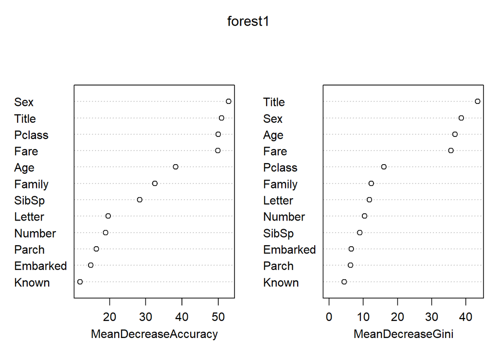

```r
set.seed(80)
forest1 <- randomForest(Survived ~ ., data = train, ntree = 2000, importance = TRUE)
varImpPlot(forest1)
```

```r
pred1 <- predict(forest1, newdata = test)
table(test$Survived, pred1 == 1)
```

```
##
##     FALSE TRUE
##   0   149   16
##   1    24   79
```

```r
(table(test$Survived, pred1 == 1)[1,1] + table(test$Survived, pred1 == 1)[2,2])/nrow(test)
```

```
## [1] 0.8507463
```

I use the information in the mean decrease in accuracy graph and the mean decrease in gini graph to come up with the following random forest as the best random forest. I do a little bit of guess and check to come up with the forest that provides the highest test set accuracy.

```r
set.seed(80)
forest1 <- randomForest(Survived ~ Age + Pclass + Fare + Family + Title + Letter + Embarked,
                            data = train, ntree = 2000, importance = TRUE)

pred1 <- predict(forest1, newdata = test)
(table(test$Survived, pred1 == 1)[1,1] + table(test$Survived, pred1 == 1)[2,2])/nrow(test)
```

```
## [1] 0.8843284
```

Next I will make the support vector machine model. I start with the same formula as I used in the random forest.

```r
library(e1071)
```

```r
svm1 <- svm(Survived ~ Age + Pclass + Fare + Family + Title + Letter + Embarked, data = train)
pred1 <- predict(svm1, newdata = test)
(table(test$Survived, pred1 == 1)[1,1] + table(test$Survived, pred1 == 1)[2,2])/nrow(test)
```

```
## [1] 0.8432836
```

I add and remove variables to find the best accuracy on the test set and come up with the following model.

```r
svm1 <- svm(Survived ~ . - Letter - Sex - Known - Number - SibSp - Embarked, data = train)
pred1 <- predict(svm1, newdata = test)
(table(test$Survived, pred1 == 1)[1,1] + table(test$Survived, pred1 == 1)[2,2])/nrow(test)
```

```
## [1] 0.8544776
```

The third model is logistic regression. I start with the formula I used for the support vector machine model.

```r
log1 <- glm(Survived ~ . - Letter - Sex - Known - Number - SibSp - Embarked,
               data = train, family = "binomial")
```

When I try to use the predict function with my logistic regression model I get an error stating “factor Letter has new levels T”. I inspect the factor levels of the train data frame and the test dataframe.

```r
table(train$Letter)
```

```
##
##   A   B   C   D   E   F   G   T UNK
##  12  33  41  21  23   8   4   0 481
```

```r
table(test$Letter)
```

```
##
##   A   B   C   D   E   F   G   T UNK
##   3  14  18  12   9   5   0   1 206
```

The logistic regression model doesn’t know what to do with the T factor in the test set because it wasn’t given one in the training set. The fix is to set the T to “UNK”

```r
test$Letter[which(test$Letter == "T")] <- "UNK"
```

I retry the logistic regression model.

```r
log1 <- glm(Survived ~ . - Letter - Sex - Known - Number - SibSp - Embarked,
           data = train, family = "binomial")

pred1 <- predict(log1, newdata = test, type = "response")
(table(test$Survived, pred1 > .5)[1,1] + table(test$Survived, pred1 > .5)[2,2])/nrow(test)
```

```
## [1] 0.8358209
```

I add and remove variables until I get the best accuracy on the test set.

```r
log1 <- glm(Survived ~ . - SibSp - Parch - Embarked - Sex - Embarked,
           data = train, family = "binomial")

pred1 <- predict(log1, newdata = test, type = "response")
(table(test$Survived, pred1 > .5)[1,1] + table(test$Survived, pred1 > .5)[2,2])/nrow(test)
```

```
## [1] 0.858209
```

Now that I have my three models complete, I need to make predictions on the unseen data to submit to Kaggle. I feed the submission data into each model. The logistic regression model returns a probability, so I need to determine if the passenger lives based off of the probability.

```r
forest_pred <- predict(forest1, newdata = titanic_test)
svm_pred <- predict(svm1, newdata = titanic_test)
log_pred <- predict(log1, newdata = titanic_test, type = "response")
```

```r
log_pred[which(log_pred > .5)] <- 1
log_pred[which(log_pred < .5)] <- 0
```

I set up the voting system with the vote variable by adding up the values from each model. Each model votes 1 if it believes the passenger survives and 0 if it believes the passenger perishes. Since the random forest and the support vector machine each vote 2 if the passenger lives and one if the passenger dies, I subtract two to account for that. I add the Survived column to titanic_test where my submission data is that holds the number of votes each passenger gets. Finally, zero or one votes and the passenger dies, 2 or 3 votes the passenger lives.

```r
vote <- as.numeric(forest_pred) + as.numeric(svm_pred) + log_pred - 2
titanic_test$Survived <- vote
titanic_test$Survived[which(titanic_test$Survived < 2)] <- 0
titanic_test$Survived[which(titanic_test$Survived > 1)] <- 1
```

```r
Submission <- titanic_test
Submission[,2:11] <- NULL
setwd("H:/Google Drive/Stats Projects/Data Sets")
write.csv(Submission, "Kaggle_Titanic_Submission.csv", row.names = FALSE)
```

My placement on the leaderboard can be seen on my Kaggle profile at https://www.kaggle.com/jgarcia102. At the time of writing this I am in the top 9%.